# Length biased gene sets

Laura Biggins

4 March 2019

```r
library("devtools")
ifelse(using_laptop,
       load_all("C:/Users/bigginsl/Desktop/temp/GOcategoryStats"),
       load_all("M:/GOcategoryStats")
       )
```

```
## [[1]]
## <environment: namespace:GOcategoryStats>
```

```r
par(mgp = c(2, 0.5, 0))
par(mar = par()$mar * 0.7)

library(RColorBrewer)
palette(brewer.pal(6, "Set2"))
```

Generate lists of mouse genes biased by the length of the genes.

### Import the gene info file

The gene info file contains the lengths of all the genes in the mouse genome. These can be plotted so that some thresholds for length categories can be determined.

### Lengths of genes

#### Plot out the length distribution for all the genes in Mus_musculus.GRCm38.94

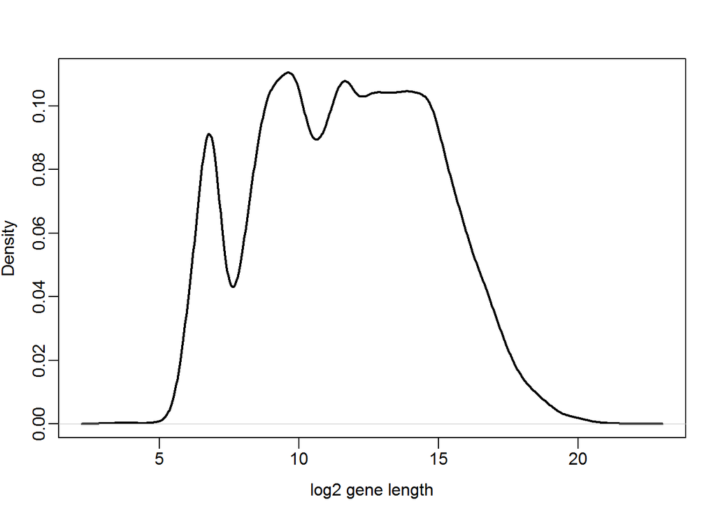

```r
x <- ifelse(using_laptop,
       genfo <- read.delim("C:/Users/bigginsl/Desktop/temp//biased_gene_lists/Mus_musculus.GRCm38.94_gene_info.txt"),
       genfo <- read.delim("M:/biased_gene_lists/Mus_musculus.GRCm38.94_gene_info.txt")
)
bg_genes <- as.vector(unique(genfo$gene_name))

plot(density(log2(genfo$length)), lwd = 2, main = "", xlab = "log2 gene length")
```

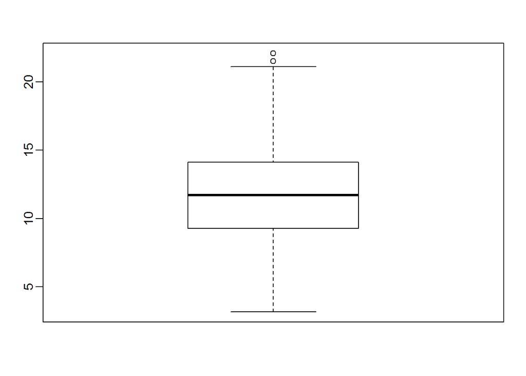

```r
boxplot(log2(genfo$length))
```

```r
long <- quantile(log2(genfo$length), probs = c(0.9, 0.95))
names(long) <- c("long", "very_long")
```

#### Select gene length thresholds.

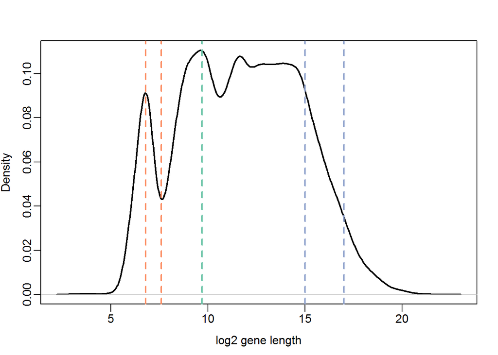

```r
plot(density(log2(genfo$length)),
     lwd  = 2,
     main = "",
     xlab = "log2 gene length"
)

thresholds2 <- c(
  very_short = 6.8,
  short1     = 7.6,
  short2     = 9.7,
  long
)


thresholds <- c(
  very_short = 6.8,
  short1     = 7.6,
  short2     = 9.7,
  long       = 15,
  very_long  = 17
)

more_less <- c(
  very_short = "less",
  short1     = "less",
  short2     = "interval",
  long       = "more",
  very_long  = "more"
)

sapply(names(thresholds), function(x){
  colours <- as.factor(more_less)
  abline(v = thresholds[x], col = colours[x], lwd = 2, lty = 2)
})
```

The thresholds

```r
thresholds
```

```
## very_short     short1     short2       long  very_long
##        6.8        7.6        9.7       15.0       17.0
```

The number of genes that remain after filtering for each length category.

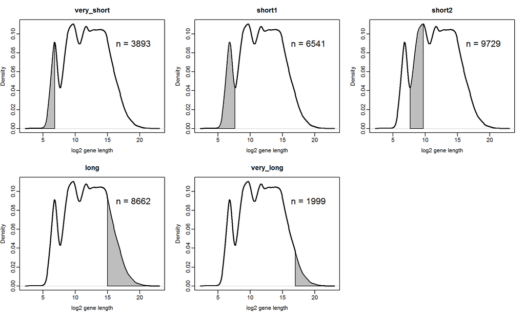

```r
dens <- density(log2(genfo$length))

par(mfrow = c(2, 3))

sapply(names(thresholds), function(length_cat){

  plot(dens, lwd = 2, xlab = "log2 gene length", main = length_cat)

  if (more_less[length_cat] == "less") {
    filt <- dens$x < thresholds[length_cat]
    polygon(
      c(dens$x[filt], thresholds[length_cat]),
      c(dens$y[filt], 0),
      col = "grey"
    )
    n_genes <- sum(log2(genfo$length) < thresholds[length_cat])

  } else if (more_less[length_cat] == "more") {
    filt <- dens$x > thresholds[length_cat]
    polygon(
      c(dens$x[filt], thresholds[length_cat]),
      c(dens$y[filt], 0),
      col = "grey"
    )
    n_genes <- sum(log2(genfo$length) > thresholds[length_cat])

  } else {
    # hard code the interval plot
     filt <- dens$x > thresholds["short1"] & dens$x < thresholds["short2"]
     polygon(
       c(thresholds["short1"], dens$x[filt], thresholds["short2"]),
       c(0, dens$y[filt], 0),
       col = "grey"
     )
     n_genes <- sum(log2(genfo$length) > thresholds["short1"] & log2(genfo$length) < thresholds["short2"] )
  }

  label_text <- paste0("n = ", n_genes)
  text(x = 19, y = 0.09, labels = label_text, cex = 1.5)
})
```

### Further pre-processing: Generating the biased gene lists

### Generating the biased gene lists within R

```r
length_genelists <- lapply(names(thresholds), function(category){

  if (more_less[category] == "less") {
    filtered_genes <- genfo$gene_name[log2(genfo$length) < thresholds[category]]
  }
  else if (more_less[category] == "more") {
    filtered_genes <- genfo$gene_name[log2(genfo$length) > thresholds[category]]
  }
  else {
      # hard code the interval plot
     filtered_genes <- genfo$gene_name[log2(genfo$length) > thresholds["short1"] &
                                         log2(genfo$length) < thresholds["short2"]]
  }
  sapply(1:100, function(i){
    filtered_genes[ceiling(runif(200, min = 0, max = length(filtered_genes) - 1))]
  })
})

names(length_genelists) <- names(thresholds)
```

```r
save(length_genelists, file = "M:/temp/length/length_genelists.rda")
```

Check they all look right

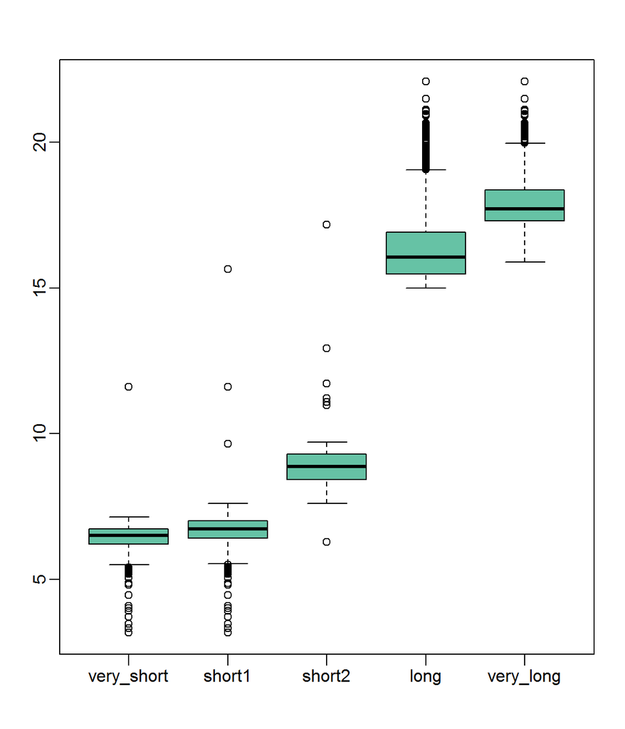

```r
par(mfrow = c(1, 1))

lengths <- lapply(length_genelists, function(x) {
  log2(genfo$length[match(unlist(x), genfo$gene_name)])
})

boxplot(lengths, col = 1)
```

The odd gene that doesn’t fall within the expected size range may be due to name duplication.

### GO overrepresentation analysis

Run the gene lists through a GO overrepresentation analysis.

```r
gene_length_results <- lapply(biased_lengths, function(length_subset){

  lapply(length_subset, function(query){
    overrep_test(all_go_categories, query, bg_genes)#, mult_test = FALSE)
  })
})

save(gene_length_results, file = "M:/GOcategoryStats/data/gene_length_results.rda")
```

We don’t want to run the GO analysis each time the document is knitted as it takes too long. The code was run once and the data saved as an .rda object that can be quickly loaded in to the R session.

See how many significant categories were returned.

```r
ifelse(using_laptop,
       load("C:/Users/bigginsl/Desktop/temp//GOcategoryStats/data/length_results.rda"),
       load("M:/GOcategoryStats/data/length_results.rda")
)
```

```
## [1] "length_results"
```

```r
number_of_results <- lapply(length_results, function(x){
  nulls_removed <- x[lapply(x,length) != 0]
  vapply(nulls_removed, nrow, FUN.VALUE = numeric(1))
})
```

The number of gene sets that returned significant results from the GO overrepresentation analysis

```r
sapply(number_of_results, length)
```

```
## very_short     short1     short2       long  very_long
##         91         48         12        100        100
```

The bean plots show the number of categories returned from each gene list. The null results have been removed.

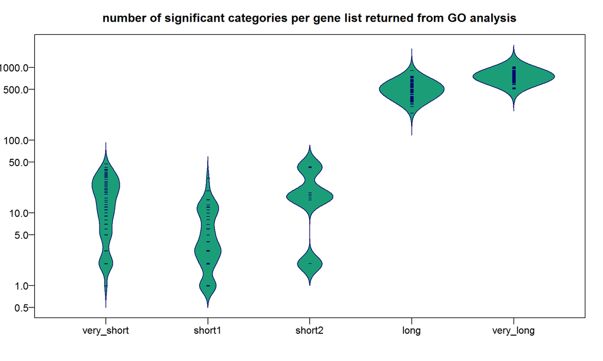

```r
par(mfrow = c(1,1))

library(beanplot)
options(scipen = 999) # disable the scientific notation

beanplot(
  number_of_results,
  what   = c(0,1,0,1),
  col    = c("#1B9E77","#06086d"),
  ll     = 0.03,
  method = "jitter",
  border = "#06086d",
  las    = 1,
  main   = "number of significant categories per gene list returned from GO analysis"
)
```

There are loads of results returned for the long genes, we’ll plot out the p and q values.

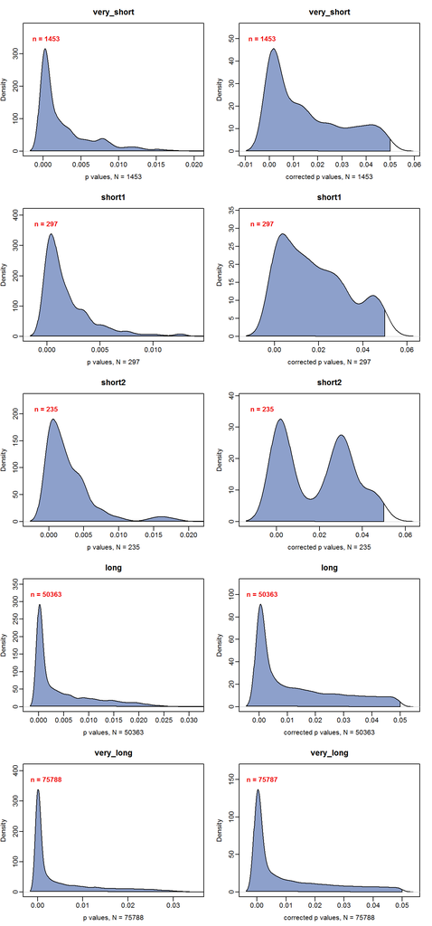

```r
p_and_q <- lapply(length_results, function(x){
  pvals <- unlist(sapply(x, `[[`, "pval"))
  qvals <- unlist(sapply(x, `[[`, "adj_pval"))
  data.frame(pvals, qvals)
})

par(mfrow = c(length(p_and_q), 2))


plot_density_highlight <- function(data_values,
                                   xlabel    = "",
                                   threshold = 0.05,
                                   title     = "",
                                   colour    = 3
                                   ){

  dens <- density(data_values)
  filt <- dens$x < threshold

  plot(dens,
    main = title,
    xlab = xlabel,
    ylim = c(0, max(dens$y) * 1.2)
  )
  polygon(
      c(dens$x[filt], threshold),
      c(dens$y[filt], 0),
      col = colour
    )
  text_label = paste0("n = ", sum(data_values < threshold))
  text(dens$x[length(dens$x)/10],
       y = max(dens$y) * 1.1,
       labels = text_label,
       font = 2,
       col  = "red2"
       )
}

sapply(names(p_and_q), function(x) {

  x_suffix <- paste0("values, N = ", nrow(p_and_q[[x]]))

  plot_density_highlight(p_and_q[[x]]$pvals,
                         title  = x,
                         xlabel = paste0("p ", x_suffix)
  )

  plot_density_highlight(p_and_q[[x]]$qvals,
                         title  = x,
                         xlabel = paste0("corrected p ", x_suffix)
  )
})
```

```r
ordered_categories <- lapply(length_results, function(length_subset){

  all_sig_categories <- unlist(sapply(length_subset, rownames))
  tabled_categories  <- table(all_sig_categories)
  tabled_categories[order(tabled_categories, decreasing = TRUE)]
})

#lapply(ordered_categories, head, n = 10)
```

Plot how many times a category appeared.

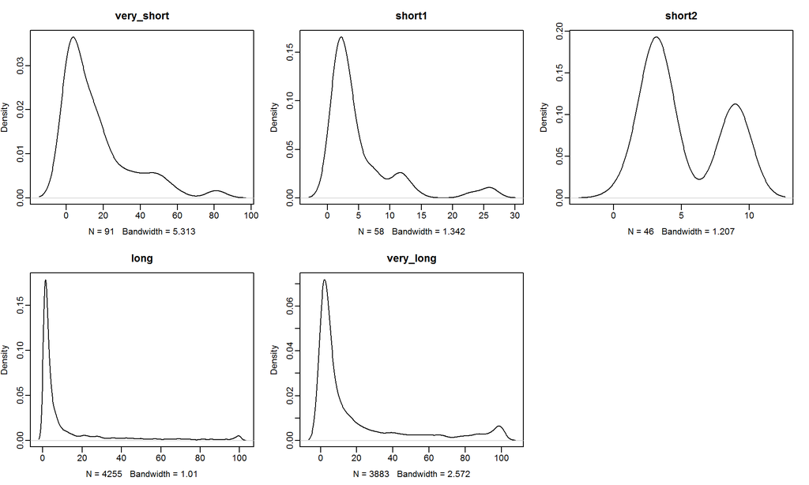

```r
par(mfrow = c(2, 3))
sapply(names(ordered_categories), function(x){
  plot(density(ordered_categories[[x]]), main = x)
})
```

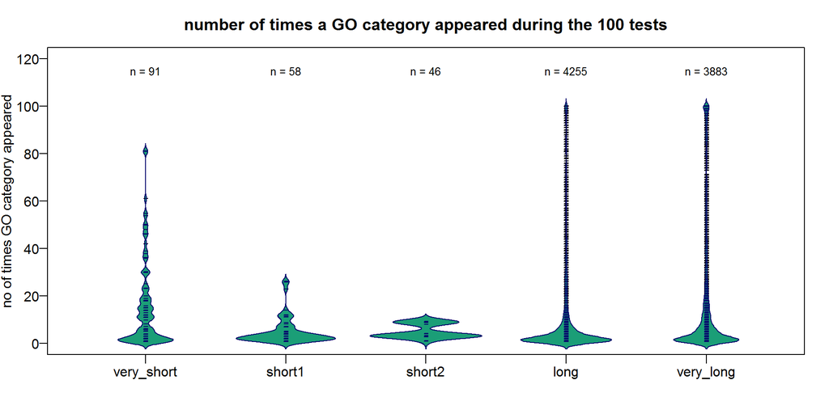

```r
par(mfrow = c(1,1))

beanplot(
  ordered_categories,
  what   = c(0,1,0,1),
  col    = c("#1B9E77","#06086d"),
  ll     = 0.03,
  method = "jitter",
  border = "#06086d",
  las    = 1,
  log    = "",
  ylim   = c(0, 120),
  main  = "number of times a GO category appeared during the 100 tests",
  ylab  = "no of times GO category appeared"
)

text(1:length(ordered_categories),
     y   = 115,
     cex = 0.8,
     labels = paste0("n = ", sapply(ordered_categories, length))
     )
```

```r
filtered_categories <- lapply(ordered_categories, function(x) x[x >= 10])
```

```r
# convert list of table to list of vectors
convert_tbl_vec <- function(list_of_tables){
  list_of_vec <- lapply(names(list_of_tables), function(x){

    vector <- as.vector(list_of_tables[[x]])
    names(vector) <- names(list_of_tables[[x]])
    vector
  })
  names(list_of_vec) <- names(list_of_tables)
  list_of_vec
}
```

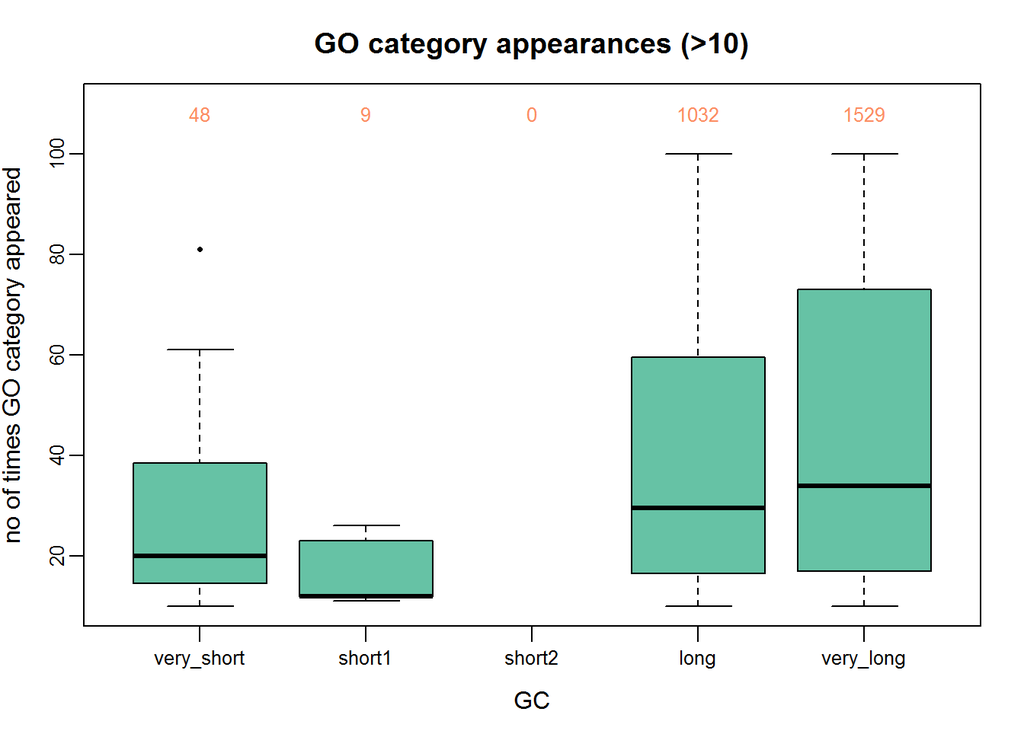

```r
filtered_categories <- lapply(ordered_categories, function(x) x[x >= 10])

filtered_categories_vec <- convert_tbl_vec(filtered_categories)

boxplot(filtered_categories_vec,
        main = "GO category appearances (>10)",
        ylab = "no of times GO category appeared",
        xlab = "GC",
        pch  = 16,
        cex  = 0.5,
        col  = 1,
        cex.axis = 0.8,
        ylim = c(10, 110)
        )

text(1:22,
     y   = 108,
     cex = 0.8,
     col = 2,
     labels = sapply(filtered_categories_vec, length)
     )
```

```r
filtered_categories <- lapply(ordered_categories, function(x) x[x >= 10])

beanplot(
  filtered_categories,
  what   = c(0,1,0,1),
  col    = c("#1B9E77","#06086d"),
  ll     = 0.03,
  method = "jitter",
  border = "#06086d",
  las    = 1,
  log    = "",
  ylim   = c(10, 120),
  main   = "GO category appearances (>10)",
  ylab   = "no of times GO category appeared"
)

text(1:length(ordered_categories),
     y   = 115,
     cex = 0.8,
     labels = paste0("n = ", sapply(filtered_categories, length))
     )
```

[output not shown]

Create a dataset that contains these suspect set of categories

```r
suspects <- lapply(ordered_categories, function(x) names(x[x >= 10]))

sapply(suspects, length)
```

```
## very_short     short1     short2       long  very_long
##         48          9          0       1032       1529
```

```r
print_sums <- function(set1, set2, not_in = FALSE) {
  ifelse(
    not_in,
    print(sum(!set1 %in% set2)),
    print(sum(set1 %in% set2))
  )
}

with(suspects, {
  print_sums(short1, very_short)
  print_sums(short1, very_short, TRUE)
  print_sums(very_short, short2)
  print_sums(long, very_long)
  print_sums(long, very_long, TRUE)
})
```

```
## [1] 9
## [1] 0
## [1] 0
## [1] 919
## [1] 113
```

```
## [1] 113
```

All of the categories in the short1 category are found in the very short category so these can be reduced to one category. The short2 set do not overlap and can just be renamed to “short”

The very_long and long categories have a lot of overlapping categories so I’ll remove any from the long category that are found in the very_long category.

```r
suspects$long <- with(suspects, long[!long %in% very_long])
suspects$short1 <- with(suspects, short1[!short1 %in% very_short])
#suspects$short1 <- NULL
#names(suspects) <- gsub(names(suspects), pattern = "short2", replacement = "short")
sapply(suspects, length)
```

```
## very_short     short1     short2       long  very_long
##         48          0          0        113       1529
```

```r
suspects <- suspects[sapply(suspects, length) > 0]
sapply(suspects, length)
```

```
## very_short       long  very_long
##         48        113       1529
```

```r
#, eval=FALSE}
# write out file with unix line endings
for (i in 1:length(suspects)){

  ifelse(using_laptop,
         filename <- paste0("C:/Users/bigginsl/Desktop/temp/biased_gene_lists/identified_categories/", names(suspects)[i], ".txt"),
         filename <- paste0("M:/biased_gene_lists/identified_categories/", names(suspects)[i], ".txt")
  )
  output_file <- file(filename, "wb")

  write.table(
    file      = output_file,
    x         = suspects[[i]],
    row.names = FALSE,
    col.names = FALSE,
    quote     = FALSE
  )

  close(output_file)
}
```